# Time series of Environmental Sensors: data inputation

## Question 2. Fill the gaps with a suitable method/s and justify the use of it.

```r
seqTime <- system.time(
  micesnow<- miceRanger(
    snow_pyr
    , m=3
    , maxiter = 5
    , returnModels = TRUE
    , verbose=TRUE
  )
)
```

```
##
## Process started at 2022-04-04 20:45:50
##
## dataset 1
## iteration 1   | snow_area_km2
## iteration 2   | snow_area_km2
## iteration 3   | snow_area_km2
## iteration 4   | snow_area_km2
## iteration 5   | snow_area_km2
##
## dataset 2
## iteration 1   | snow_area_km2
## iteration 2   | snow_area_km2
## iteration 3   | snow_area_km2
## iteration 4   | snow_area_km2
## iteration 5   | snow_area_km2
##
## dataset 3
## iteration 1   | snow_area_km2
## iteration 2   | snow_area_km2
## iteration 3   | snow_area_km2
## iteration 4   | snow_area_km2
## iteration 5   | snow_area_km2
```

Let’s check the how it went (data imputation diagnosis tools):

1. plotModelError

Random Forests give us a cheap way to determine model error without cross validation. Each model returns the OOB accuracy for classification, and r-squared for regression. We can see how these converged as the iterations progress:

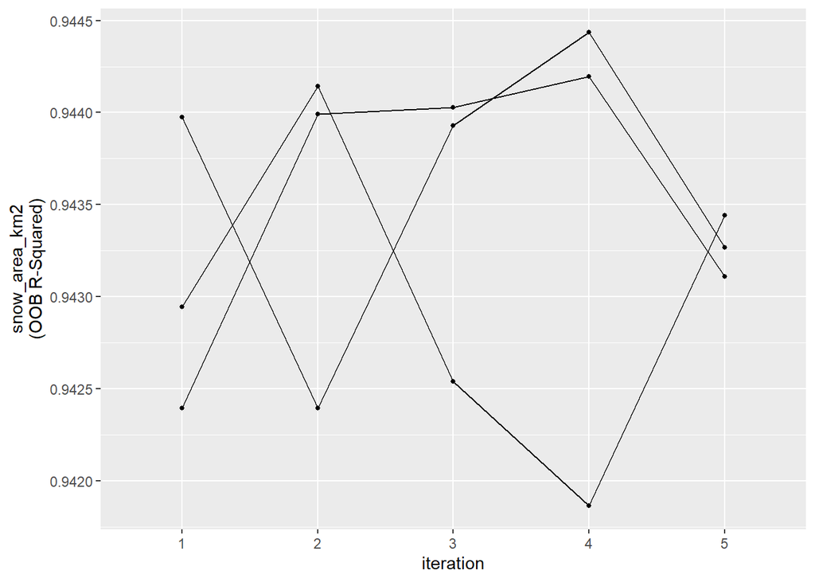

```r
plotModelError(micesnow,vars='allNumeric')
```

2. plotDistributions

Shows the distribution of the original data and the distribution of the imputed data. The gap filling went OK

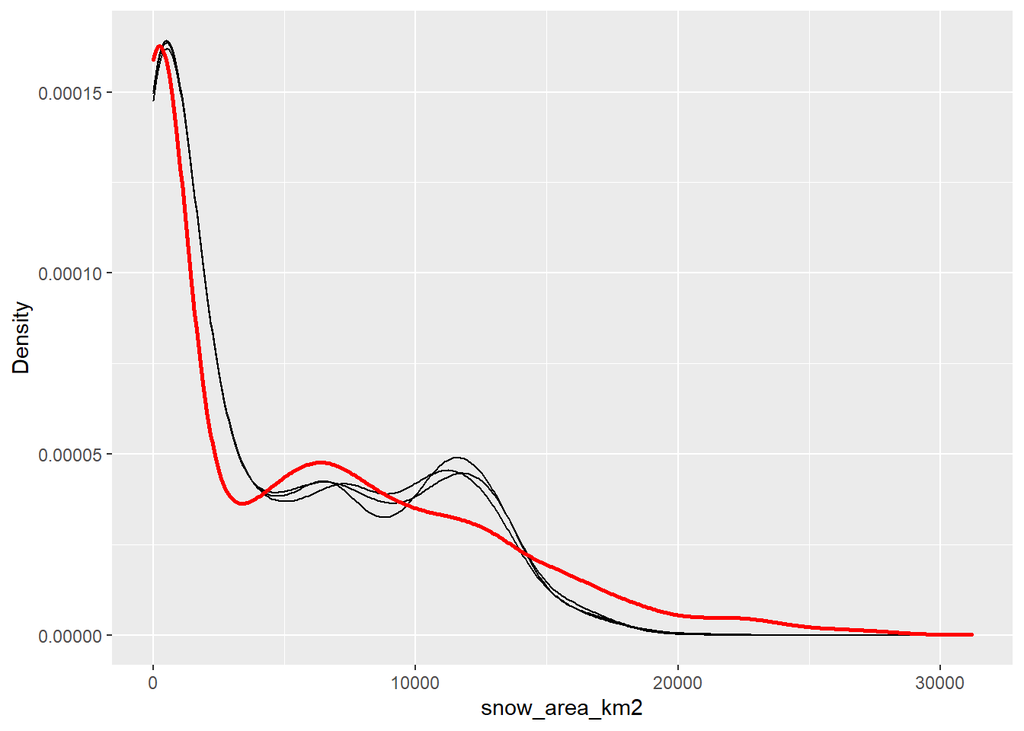

```r
plotDistributions(micesnow)
```

The red line is the density of the original, nonmissing data. The smaller, black lines are the density of the imputed values in each of the datasets. If these don’t match up, it’s not a problem, however it may tell you that your data was not Missing Completely at Random (MCAR).

List imputed datasets:

```r
dataList <- completeData(micesnow)
ds1 <- dataList[[1]]
ds2 <- dataList[[2]]
ds3 <- dataList[[3]]
```

Visualization of time series with (Measured data) and without (Imputed data) gaps:

[figure not shown]

```r
par(mfrow= c(1,1), mar = c(3,4.5,1,1))
plot(ds1$snow_area_km2, type="l", col ="green",
     xlab = "Time", ylab = "Temperature (ºC)")
lines(ds2$snow_area_km2, type="l", col="green")
lines(ds3$snow_area_km2, type="l", col="green")
lines(snow_pyr$snow_area_km2, type="l", col=1)
legend("topleft", c("Measured data", "Imputed data"), lty =1, col = c(1,3))
```

Let’s add the original dataset (with no gaps) and see how they compare?

```r
snow_pyr_full <- read_csv('00_course datasets/snow_pyrenees.csv')
```

[figure not shown]

```r
par(mfrow= c(1,1), mar = c(3,4.5,1,1))
plot(ds1$snow_area_km2, type="l", col ="#00FF0040",
     xlab = "Time", ylab = "Temperature (ºC)")
lines(ds2$snow_area_km2, type="l", col="#00FF0040")
lines(ds3$snow_area_km2, type="l", col="#00FF0040")
#lines(snow_pyr$snow_area_km2, type="l", col=1)
lines(snow_pyr_full$snow_area_km2, type="l", col="grey30", lwd=0.1)
legend("topleft", c("Measured data", "Imputed data"), lty =1, col = c(1,3))
```

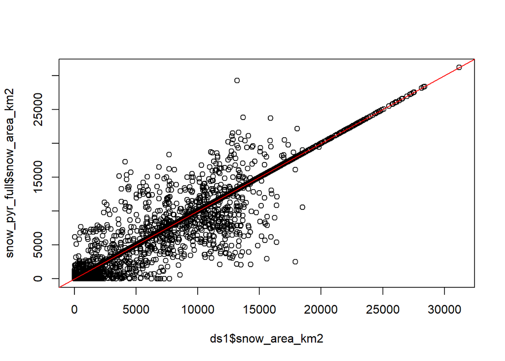

```r
plot(ds1$snow_area_km2,snow_pyr_full$snow_area_km2)
abline(0,1, col="red")
```

[^1]: CREAF, gomez.gener87@gmail.com